# Zmix Tagalong Example

Zoe van Havre

11 December 2015

# Zmix (beta version)

An R package for overfitting Bayesian mixture models with an unknown number of components.

Link to paper: http://journals.plos.org/plosone/article?id=10.1371/journal.pone.0131739

Please cite: **van Havre Z, White N, Rousseau J, Mengersen K (2015) Overfitting Bayesian Mixture Models with an Unknown Number of Components. PLoS ONE 10(7): e0131739. doi: 10.1371/journal.pone.0131739**

**Before use**: currently working on updating documentation etc, please contact me for info / questions.

The code below is an example of a typical analysis:

```r
library(devtools)
library(roxygen2)
install_github("zoevanhavre/Zmix")
```

```r
library(Zmix)
```

## Simulation example

Generate 100 observations from a three component mixture of univariate Gaussian distributions.

```r
set.seed(1)
dat1 <- c(rnorm(20, mean = -1), rnorm(70, mean = 4), rnorm(10, mean = 10))
```

To run **Zmix** on univariate Gaussian mixtures, assuming all component means and variances are unknown, use the function: `Zmix_univ_tempered(y, k = 10, iter = 5000, tau = 1, isSim=FALSE, alphas = c(30, 20, 10, 5, 3, 1, 0.5, 1/2^(c(2, 3, 4, 5, 6, 8, 10, 15, 20, 30))))`.

A progress bar is included to help you keep track of things, reassured in the fact the function has not broken or become stuck.

```r
run1 <- Zmix_univ_tempered(y = dat1, k = 10, iter = 1000)
```

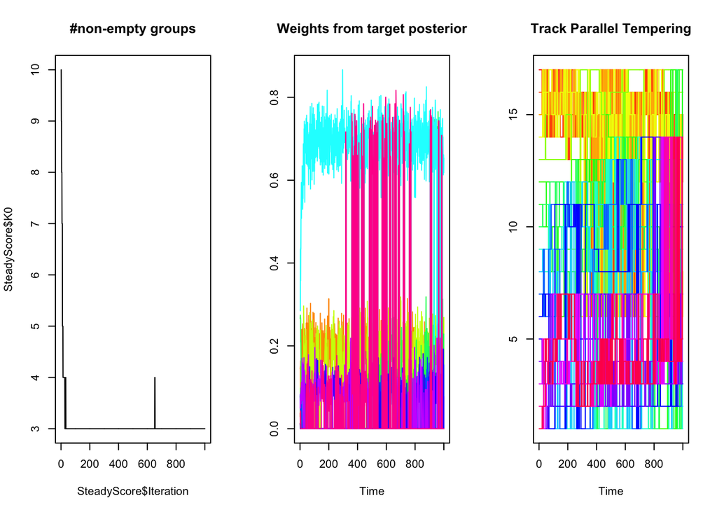

```r
# this is just a few iterations for a fast example, in practice please use
# more (~20,000 for testing, ~50,000 for final results)
```

One figure is directly created, and includes three plots: The number of occupied components by iteration, the trace plot of the weights parameter, and a visual tracker of the parallel tempering algorithm *(a colour is assigned to each parallel sampler and the lines of appropriate colour are swapped when tempering takes place between respective chains)*.

### Output and label switching

The output directly produced is not very useful thanks to label switching and the multiple Prior Parallel Tempering chains used in the Zmix algorithm.

To simplify post-processing, a wrapper function called `Process_Output_Zmix` is available which does a number of useful tasks, including separating out iterations represening models with a different number of occupied components, and undoing the label switching on each model thus extracted. Parameters of some importance are:

**`Process_Output_Zmix( )`**

- **`Burn`**: Burn-in to remove.
- **`Pred_Reps`**: Number of posterior predictive replicates to take for model checking, most importantly for plot of predicted densities VS true density. This is a very useful plot to epxlore not only the fit of the proposed model, but identifying specific areas of potential weakness. A large value like 10,000 is nice for publication purposes, but significantly slows down this function.
- **`Zswitch_Sensitivity=0.05`**: A parameter used in the label switching function. It can be interpreted as the maximum allowed amount percentage of variation between the allocations of a component from one iteration to the reference. i.e. as default, if more than $95/%$ of the observations allocated to component $j$ are found to have the same component label, the relabelling is done instantly, otherwise extra information is drawn from the other parameters to ensure the labelling is resolved optimally. Reducing this value can slow things down, and will cause issues when too many groups are present, but lowering to 0.01 has not caused any issues in my experience and can resolve rare inconsistencies.  
  -**`LineUp=1`**: For final output, if groups should be names by by 1= decreasing weights (biggest group first), 2 = means, increasing (lowest mean first), and 3 =increasing Variance (use of you expect two components to have identical means and weights.). This parameter only affects the final name of the groups, and shouldnt affect the relabelling algorithm.
- **`Plot_Title`**: Title of plot created…
- **`SaveFileName`**: Name of plot file. no spaces!

Please ensure you are working in a personal/project directory at this point as plots are created automatically with the `Process_Output_Zmix` function.

```r
setwd("Your_Output_Folder")
```

```r
pp_run1 <- Process_Output_Zmix(run1, Pred_Reps = 500, Zswitch_Sensitivity = 0.05,
    LineUp = 1, Plot_Title = "Sim 1 Example of Zmix", SaveFileName = "Zmix_Run1",
    Burn = 300)
```

```
## NULL
## NULL
##   K0 Probability      MAE      MSE  Pmin Pmax Concordance     MAPE
## 1  3           1 70.85911 79.86401 0.786 0.68     0.92488 84.32185
##       MSPE
## 1 127.5611
```

Graphical Results:

Model with 3 groups:

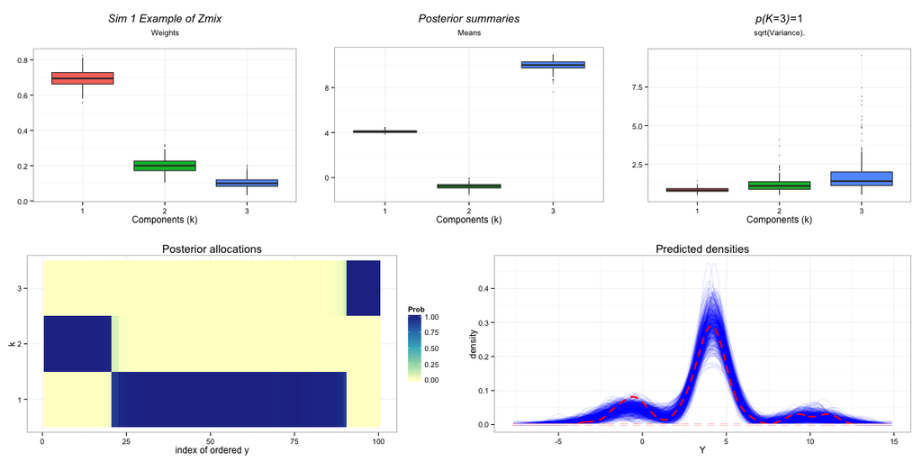

```
## NULL
## NULL
##   K0 Probability      MAE      MSE  Pmin Pmax Concordance     MAPE
## 1  3           1 70.85911 79.86401 0.754 0.68     0.92622 84.17322
##       MSPE
## 1 126.5534
```

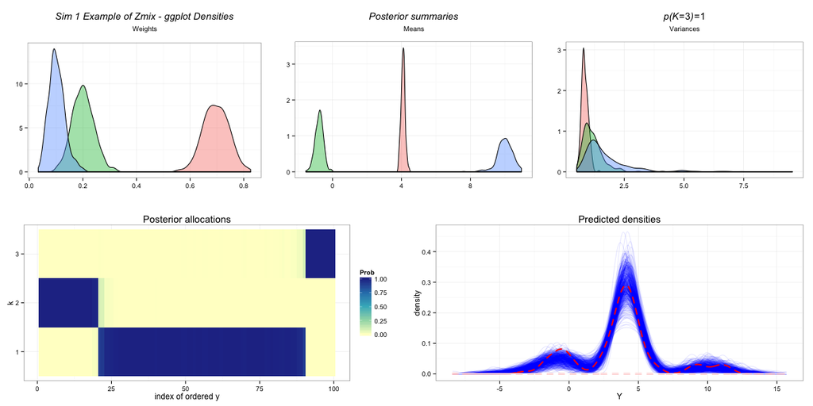

```r
pp_run1_2 <- Process_Output_Zmix(run1, Pred_Reps = 500, Zswitch_Sensitivity = 0.05,
    LineUp = 1, Plot_Title = "Sim 1 Example of Zmix - ggplot Densities", SaveFileName = "Zmix_Run1_densitiesInstead",
    Burn = 300, PlotType = "Density")
```

### Output of this function is a list of:

1: Result summary, including (by column) the parameter, the group number, the mean and 95% CI’s of the parameter estimates for all models (**Bayesian ones, it should be needless to say**). The label switching has been resolved within the post processing function.

```r
pp_run1[[1]]
```

```
##   variable factor(k)              value K0
## 1        P         1      0.7(0.6,0.78)  3
## 2       Mu         1    4.09(3.86,4.33)  3
## 3      Sig         1    0.85(0.61,1.13)  3
## 4        P         2     0.2(0.13,0.28)  3
## 5       Mu         2 -0.77(-1.25,-0.33)  3
## 6      Sig         2    1.19(0.64,2.31)  3
## 7        P         3     0.1(0.05,0.17)  3
## 8       Mu         3     10(8.95,10.82)  3
## 9      Sig         3    1.78(0.78,5.02)  3
```

2: Model fit values

```r
pp_run1[[2]]
```

```
##   K0 Probability      MAE      MSE  Pmin Pmax Concordance     MAPE
## 1  3           1 70.85911 79.86401 0.786 0.68     0.92488 84.32185
##       MSPE
## 1 127.5611
```

3: Posterior allocations (list over all models found)

```r
head(pp_run1[[3]][[1]])
```

```
## [1] 2 2 2 2 2 2
## Levels: 1 2 3
```

```r
# head(pp_run1[[3]][[2]]) Exists if there is a second model only.
```

4: Posterior Allocation probabilities for each observation and each non-empty group (list over all models found)

```r
head(pp_run1[[4]][[1]])
```

```
##   Yid k Prob
## 1   1 1    0
## 2   1 2    1
## 3   1 3    0
## 4   2 1    0
## 5   2 2    1
## 6   2 3    0
```

```r
# head(pp_run1[[4]][[2]]) # When there is a second model, etc
```

5: Unswitched parameters (list over all models found)

```r
# head(pp_run1[[5]][[1]][[1]]) # Parameters head(pp_run1[[5]][[1]][[2]]) #
# Allocations (Zs)
```